# R exercise 2: Data Preprocessing

Kelsey Gonzalez and Laura Werthmann

September 17, 2019

Load the data

```r
rm(list=ls())
suppressPackageStartupMessages(require(dplyr))
load("LifeExpectancyData.Rdata")
dplyr::glimpse(data)
```

```
## Observations: 2,938
## Variables: 22
## $ Country                           <chr> "Afghanistan", "Afghanistan"...
## $ Year                              <dbl> 2015, 2014, 2013, 2012, 2011...
## $ Status                            <chr> "Developing", "Developing", ...
## $ `Life expectancy`                 <dbl> 65.0, 59.9, 59.9, 59.5, 59.2...
## $ `Adult Mortality`                 <dbl> 263, 271, 268, 272, 275, 279...
## $ `infant deaths`                   <dbl> 62, 64, 66, 69, 71, 74, 77, ...
## $ Alcohol                           <dbl> 0.01, 0.01, 0.01, 0.01, 0.01...
## $ `percentage expenditure`          <dbl> 71.279624, 73.523582, 73.219...
## $ `Hepatitis B`                     <dbl> 65, 62, 64, 67, 68, 66, 63, ...
## $ Measles                           <dbl> 1154, 492, 430, 2787, 3013, ...
## $ BMI                               <dbl> 19.1, 18.6, 18.1, 17.6, 17.2...
## $ `under-five deaths`               <dbl> 83, 86, 89, 93, 97, 102, 106...
## $ Polio                             <dbl> 6, 58, 62, 67, 68, 66, 63, 6...
## $ `Total expenditure`               <dbl> 8.16, 8.18, 8.13, 8.52, 7.87...
## $ Diphtheria                        <dbl> 65, 62, 64, 67, 68, 66, 63, ...
## $ `HIV/AIDS`                        <dbl> 0.1, 0.1, 0.1, 0.1, 0.1, 0.1...
## $ GDP                               <dbl> 584.25921, 612.69651, 631.74...
## $ Population                        <dbl> 33736494, 327582, 31731688, ...
## $ `thinness  1-19 years`            <dbl> 17.2, 17.5, 17.7, 17.9, 18.2...
## $ `thinness 5-9 years`              <dbl> 17.3, 17.5, 17.7, 18.0, 18.2...
## $ `Income composition of resources` <dbl> 0.479, 0.476, 0.470, 0.463, ...
## $ Schooling                         <dbl> 10.1, 10.0, 9.9, 9.8, 9.5, 9...
```

# Data Preprocessing Exercise 2

Review of World Health Organization’s Life Expectancy Data taken from [Kaggle](https://www.kaggle.com/kumarajarshi/life-expectancy-who).

# String processing

Status is character class but it should be a factor. Let’s convert it.

```r
str(data$Status)
```

```
##  chr [1:2938] "Developing" "Developing" "Developing" "Developing" ...
```

```r
data$Status = as.factor(data$Status)
class(data$Status)
```

```
## [1] "factor"
```

# dealing with unknown values: remove observations or columns with many NAs

```r
suppressPackageStartupMessages(require(dplyr))
missing.value.rows <- filter(data, !complete.cases(data))
missing.value.rows
```

```
## # A tibble: 1,289 x 22
##    Country  Year Status `Life expectanc~ `Adult Mortalit~ `infant deaths`
##    <chr>   <dbl> <fct>             <dbl>            <dbl>           <dbl>
##  1 Algeria  2015 Devel~             75.6               19              21
##  2 Algeria  2003 Devel~             71.7              146              20
##  3 Algeria  2002 Devel~             71.6              145              20
##  4 Algeria  2001 Devel~             71.4              145              20
##  5 Algeria  2000 Devel~             71.3              145              21
##  6 Angola   2015 Devel~             52.4              335              66
##  7 Angola   2006 Devel~             47.7              381              90
##  8 Angola   2005 Devel~             47.4              382              92
##  9 Angola   2004 Devel~             47.1              386              94
## 10 Angola   2003 Devel~             46.8              388              95
## # ... with 1,279 more rows, and 16 more variables: Alcohol <dbl>,
## #   `percentage expenditure` <dbl>, `Hepatitis B` <dbl>, Measles <dbl>,
## #   BMI <dbl>, `under-five deaths` <dbl>, Polio <dbl>, `Total
## #   expenditure` <dbl>, Diphtheria <dbl>, `HIV/AIDS` <dbl>, GDP <dbl>,
## #   Population <dbl>, `thinness 1-19 years` <dbl>, `thinness 5-9
## #   years` <dbl>, `Income composition of resources` <dbl>, Schooling <dbl>
```

how many NAs in each row?

```r
# This function counts the number of NAs in a row.
apply(data, 1, function(x) sum(is.na(x)))
```

```
## [1] 0 0 0 0 0
##  [ reached getOption("max.print") -- omitted 2933 entries ]
```

how many NAs in each column?

```r
sort(apply(data, 2, function(x) sum(is.na(x))))
```

```
##                         Country                            Year
##                               0                               0
##                          Status                   infant deaths
##                               0                               0
##          percentage expenditure                         Measles
##                               0                               0
##               under-five deaths                        HIV/AIDS
##                               0                               0
##                 Life expectancy                 Adult Mortality
##                              10                              10
##                           Polio                      Diphtheria
##                              19                              19
##                             BMI            thinness  1-19 years
##                              34                              34
##              thinness 5-9 years                       Schooling
##                              34                             163
## Income composition of resources                         Alcohol
##                             167                             194
##               Total expenditure                             GDP
##                             226                             448
##                     Hepatitis B                      Population
##                             553                             652
```

Because of the high number of Hepatitis B cases missing, we will remove this column from our dataset. Our research questions do not pertain to Hepatitis.

```r
data = subset(data,select = -c(`Hepatitis B`))
```

Because there is such a high occurence of missing Population data,we will merge in the gapminder dataset and match on coutnry and year.

```r
suppressPackageStartupMessages(require(gapminder))
data2 <- inner_join(data, gapminder_unfiltered, by = c("Year" = "year", "Country" = "country"))
# test how well new and old pop are correlated (should be extremely high)
data2$pop = as.numeric(data2$pop)
data_na_rm = na.omit(data2)
cor(data_na_rm$Population, data_na_rm$pop)
```

```
## [1] 0.4646644
```

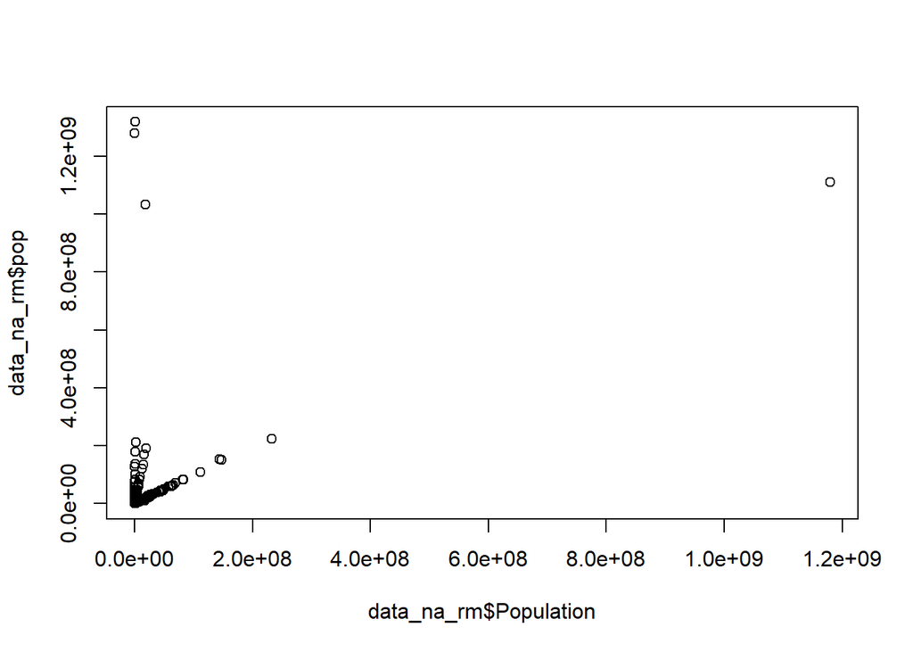

```r
plot(data_na_rm$Population, data_na_rm$pop)
```

why is the correlation so low on the original data?

```r
data_na_rm[data_na_rm$pop > 1.2e+09,]
```

```
## # A tibble: 2 x 25
##   Country  Year Status `Life expectanc~ `Adult Mortalit~ `infant deaths`
##   <chr>   <dbl> <fct>             <dbl>            <dbl>           <dbl>
## 1 China    2007 Devel~             74.4               96             285
## 2 China    2002 Devel~             72.7               16             422
## # ... with 19 more variables: Alcohol <dbl>, `percentage
## #   expenditure` <dbl>, Measles <dbl>, BMI <dbl>, `under-five
## #   deaths` <dbl>, Polio <dbl>, `Total expenditure` <dbl>,
## #   Diphtheria <dbl>, `HIV/AIDS` <dbl>, GDP <dbl>, Population <dbl>,
## #   `thinness 1-19 years` <dbl>, `thinness 5-9 years` <dbl>, `Income
## #   composition of resources` <dbl>, Schooling <dbl>, continent <fct>,
## #   lifeExp <dbl>, pop <dbl>, gdpPercap <dbl>
```

It looks like the original data has some scaling issues of their population variable. Gapminder is consistent, so we will use pop from there and omit Population.

```r
data2 = subset(data2, select = -`Population`)
```

What about GDP?

```r
cor(data_na_rm$GDP, data_na_rm$gdpPercap)
```

```
## [1] 0.7703025
```

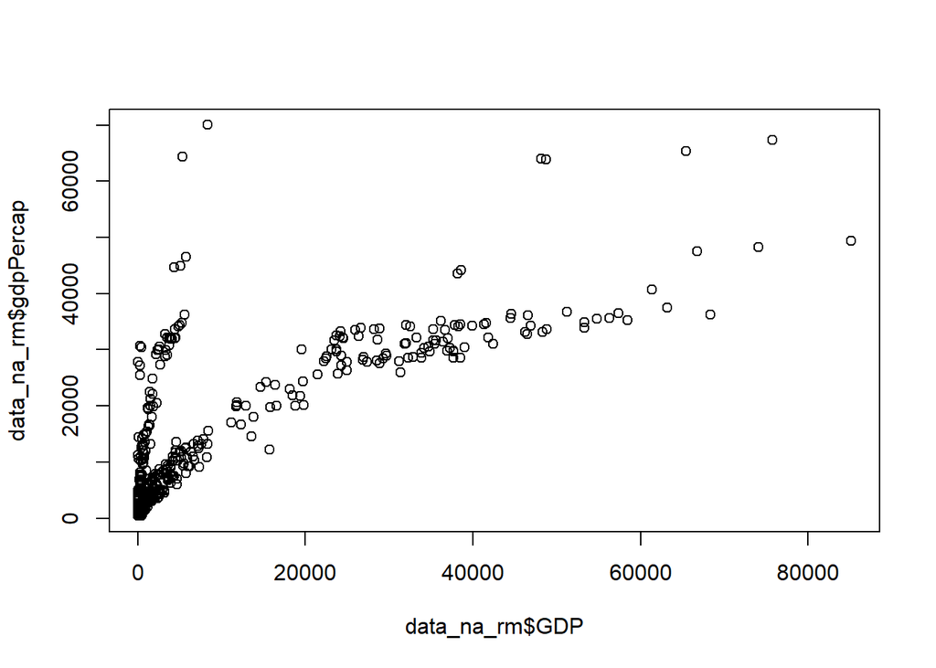

```r
plot(data_na_rm$GDP, data_na_rm$gdpPercap)
```

What about Life Expectancy?

```r
cor(data_na_rm$`Life expectancy`, data_na_rm$lifeExp)
```

```
## [1] 0.9673343
```

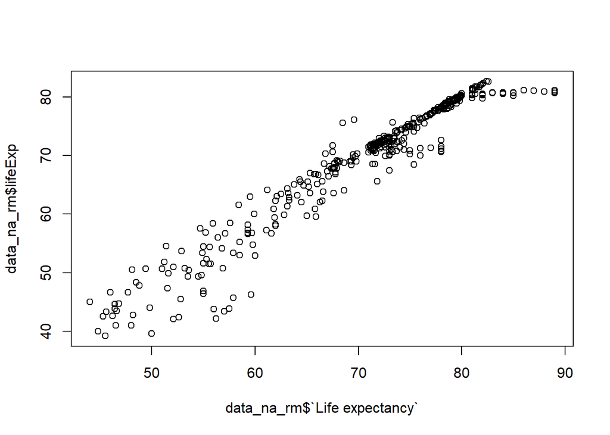

```r
plot(data_na_rm$`Life expectancy`, data_na_rm$lifeExp)
```

```r
data2 = subset(data2, select = -`lifeExp`)
```

# scaling and normalization

Most of our variables are zero inflated and/or right skewed. Let’s take a few (infant deaths, GDP, Diphtheria) and normalize and scale them.

Z-Score scaling of infant deaths

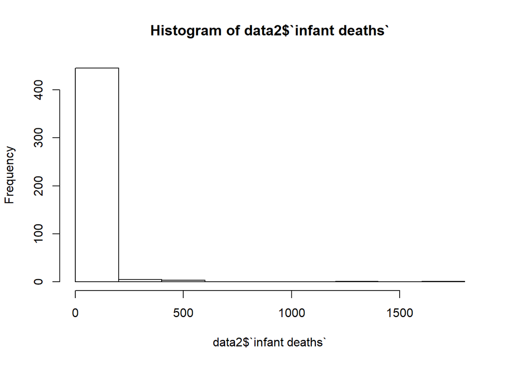

```r
hist(data2$`infant deaths`)
```

```r
zscore = function(x){return((x-mean(x))/(sd(x)))}
data2$infant_scaled = zscore(data2$`infant deaths`)
data2 %>% select(`infant deaths`, infant_scaled) %>% head()
```

```
## # A tibble: 6 x 2
##   `infant deaths` infant_scaled
##             <dbl>         <dbl>
## 1              82        0.497
## 2              88        0.548
## 3               1       -0.199
## 4               1       -0.199
## 5              20       -0.0357
## 6              20       -0.0357
```

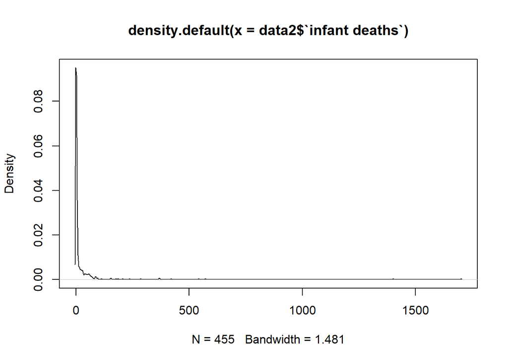

```r
plot(density(data2$`infant deaths`))
```

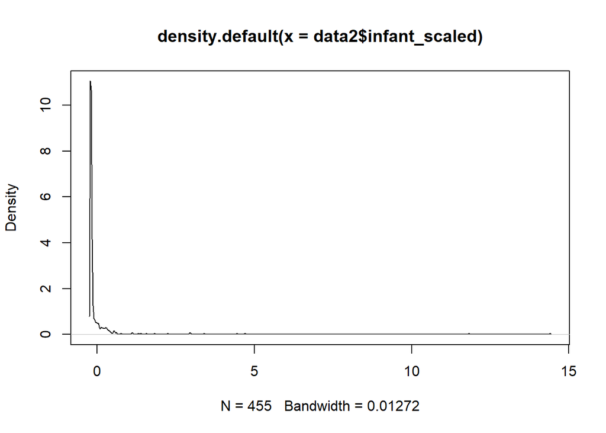

```r
plot(density(data2$infant_scaled))
```

Normalization of GDP Per Capita

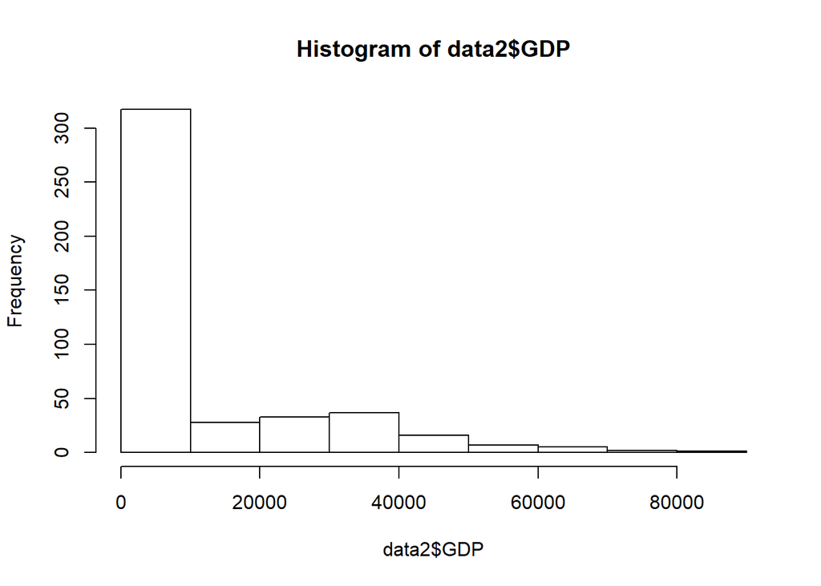

```r
hist(data2$GDP)
```

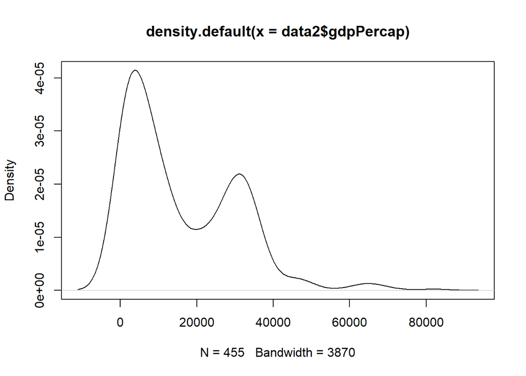

```r
data2$gdpPercaplog = log(data2$gdpPercap)

plot(density(data2$gdpPercap))
lines(density(data2$gdpPercaplog), add = TRUE)
```

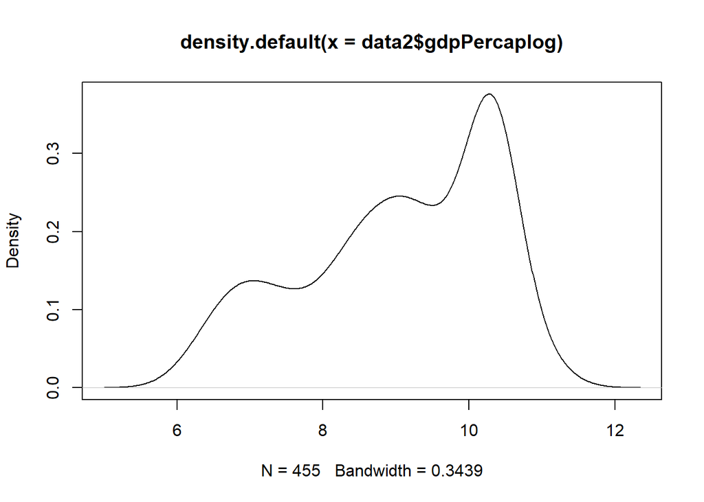

```r
# they're on different scales, so you can't really see the differences.

plot(density(data2$gdpPercaplog))
```

This normalization method doesn’t seem to be particularly useful.

Normalize Diptheria using complete normalization

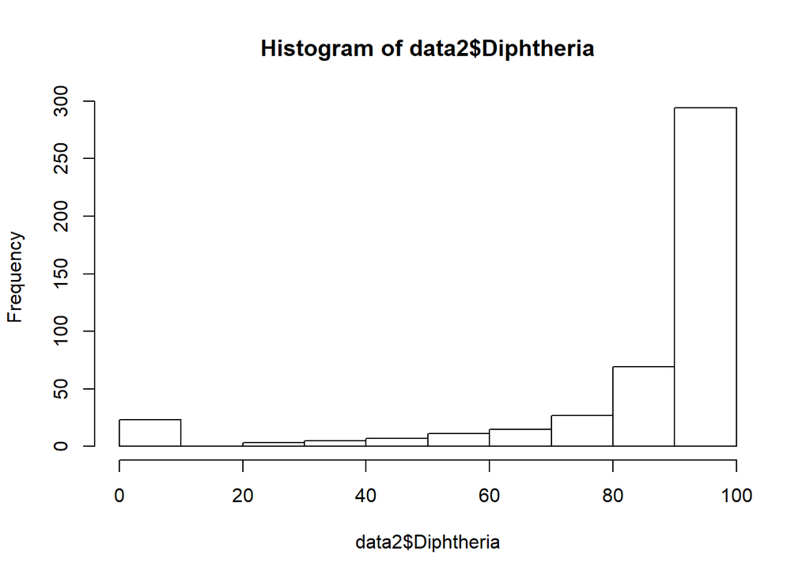

```r
hist(data2$Diphtheria)
```

```r
data2$dipnormal = scale(data2$Diphtheria, center = TRUE, scale = TRUE)
data2 %>% select(Diphtheria, dipnormal) %>% head()
```

```
## # A tibble: 6 x 2
##   Diphtheria dipnormal[,1]
##        <dbl>         <dbl>
## 1         63       -0.967
## 2         36       -2.17
## 3         98        0.592
## 4         98        0.592
## 5         95        0.458
## 6         86        0.0574
```

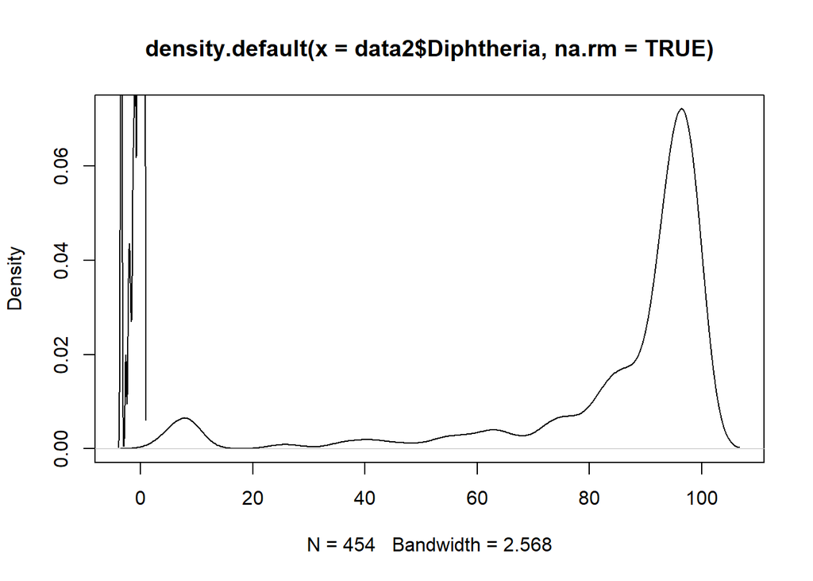

```r
plot(density(data2$Diphtheria, na.rm = TRUE))
lines(density(data2$dipnormal, na.rm = TRUE), add = TRUE)
```

# discretizing variables

Let’s create a discretized version of Life Expectancy using clustering.

```r
set.seed(1)
suppressPackageStartupMessages(library(sampling))
```

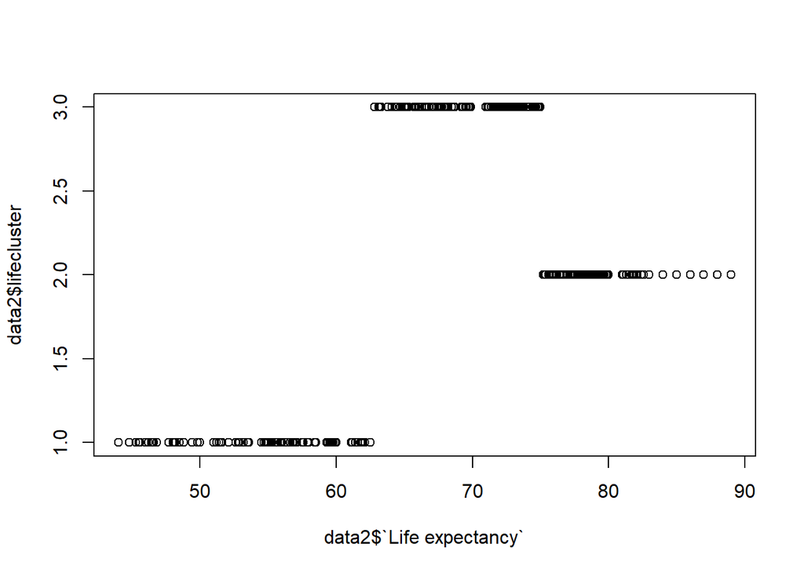

```r
s <- kmeans(data2$`Life expectancy`, 3)

data2$lifecluster <- factor(s$cluster, labels = c(`1` = 'young', `2` = 'middle',`3` = 'high'), ordered = TRUE)
rm(s)
plot(data2$`Life expectancy`, data2$lifecluster)
```

## Required Questions

> 1. What attributes are there in your data set?

Some attributes we found were based on Country economics-> GDP, Status, Total Expenditure, and Population demographics-> BMI, mortality, disease, and schooling.

> 2. Do you have highly correlated attributes? How did you find out about the correlations or lack of correlations?

```r
suppressPackageStartupMessages(library(car))
symnum(cor(data2[4:20], use = "complete.obs"))
```

```
##                                 Le AM id A pe M B ud P Te D H G t1y t5y
## Life expectancy                 1
## Adult Mortality                 ,  1
## infant deaths                         1
## Alcohol                         .        1
## percentage expenditure          .  .     . 1
## Measles                               .       1
## BMI                             .  .     .      1
## under-five deaths                     B       .   1
## Polio                           .               .    1
## Total expenditure                                      1
## Diphtheria                      .        .      .    ,    1
## HIV/AIDS                        .  .                        1
## GDP                             .  .     . B                  1
## thinness  1-19 years            ,  .  .  . .    . .  .    .   . 1
## thinness 5-9 years              .  .  .  . .    . .  . .      . +   1
## Income composition of resources ,  .     . .    .    .    . . . ,   .
## Schooling                       +  .     , .    ,    . .  .   . ,   .
##                                 Icor S
## Life expectancy
## Adult Mortality
## infant deaths
## Alcohol
## percentage expenditure
## Measles
## BMI
## under-five deaths
## Polio
## Total expenditure
## Diphtheria
## HIV/AIDS
## GDP
## thinness  1-19 years
## thinness 5-9 years
## Income composition of resources 1
## Schooling                       +    1
## attr(,"legend")
## [1] 0 ' ' 0.3 '.' 0.6 ',' 0.8 '+' 0.9 '*' 0.95 'B' 1
```

We found that GDP correlates fully with Percentage Expenditure; Under 5 deaths correlates with infant deaths; and schooling and Income composition of resources is .9 correlated.

```r
suppressPackageStartupMessages(library(DMwR2))
summary(lm(data2$GDP~ data2$`percentage expenditure`, data=data2))
```

```
##
## Call:
## lm(formula = data2$GDP ~ data2$`percentage expenditure`, data = data2)
##
## Residuals:
##     Min      1Q  Median      3Q     Max
## -9205.4 -1485.4 -1097.2   469.1 29025.3
##
## Coefficients:
##                                 Estimate Std. Error t value Pr(>|t|)
## (Intercept)                    1.536e+03  1.969e+02   7.799 4.49e-14 ***
## data2$`percentage expenditure` 5.961e+00  6.354e-02  93.812  < 2e-16 ***
## ---
## Signif. codes:  0 '***' 0.001 '**' 0.01 '*' 0.05 '.' 0.1 ' ' 1
##
## Residual standard error: 3583 on 444 degrees of freedom
##   (9 observations deleted due to missingness)
## Multiple R-squared:  0.952,  Adjusted R-squared:  0.9519
## F-statistic:  8801 on 1 and 444 DF,  p-value: < 2.2e-16
```

We also found a high correlation between GDP and percentage expenditure with a ggplot:

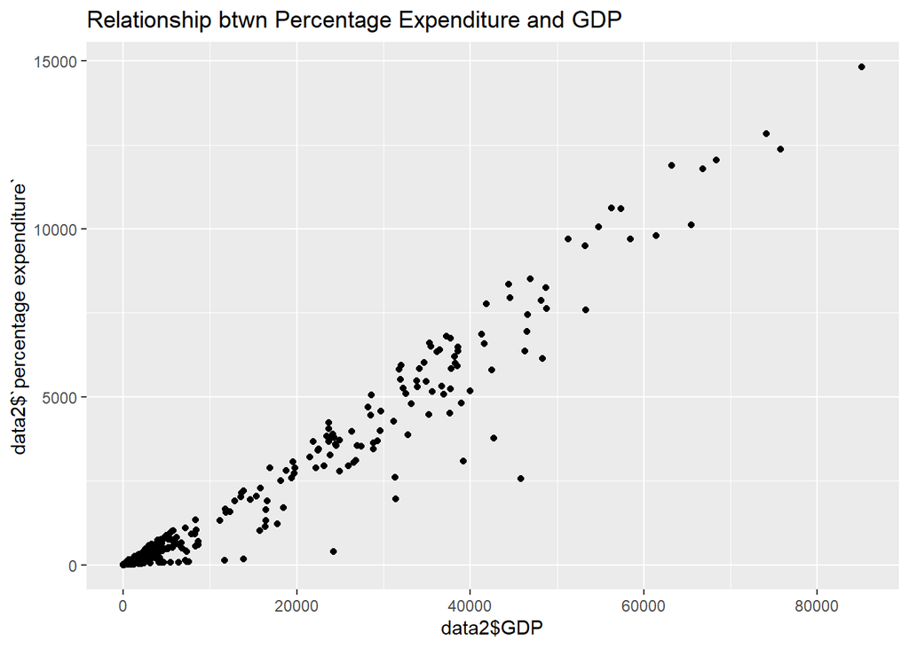

and the status of the country (Developing/Developed) shows that more developed states have a higher mean of Life Expectancy, GDP and Percentage Expenditure.

```r
aggregate(data2$`Life expectancy`, list(data2$Status), mean, na.rm=TRUE)
```

```
##      Group.1        x
## 1  Developed 78.48786
## 2 Developing 66.81596
```

```r
aggregate(data2$GDP, list(data2$Status), mean, na.rm=TRUE)
```

```
##      Group.1        x
## 1  Developed 20969.93
## 2 Developing  4546.02
```

```r
aggregate(data2$`percentage expenditure`, list(data2$Status), mean, na.rm=TRUE)
```

```
##      Group.1         x
## 1  Developed 3239.7972
## 2 Developing  501.2637
```

> 3. Do you have numerical attributes that you might want to discretize? Try at least two methods and compare the differences.

Life Expectancy can be discretized,

Categorical classification of low, med, and high of Life Expectancy rates using 3 cuts

```r
data2$category <- cut(data2$`Life expectancy`,
                              breaks = 3,
                              labels=c('young', 'middle', 'high'))
dplyr::glimpse(data2$category)
```

```
##  Factor w/ 3 levels "young","middle",..: 1 1 3 2 2 2 1 1 3 3 ...
```

earlier we binned life expectancy using clusters with the following code:

```r
set.seed(1)
suppressPackageStartupMessages(library(sampling))
s <- kmeans(data2$`Life expectancy`, 3)

data2$lifecluster <- factor(s$cluster, labels = c(`1` = 'young', `2` = 'middle',`3` = 'high'), ordered = TRUE)


dplyr::glimpse(data2$lifecluster)
summary(data2$lifecluster)
```

[output not shown]

Since we binned using two different methods, let’s see how these methods compare in their binning.

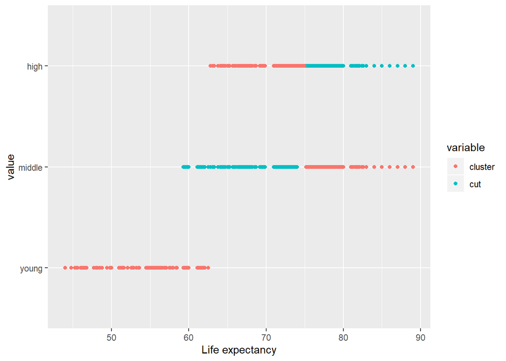

```r
ggplot(data2, aes(`Life expectancy`, y = value, color = variable)) +
    geom_point(aes(y = category, col = "cut")) +
    geom_point(aes(y = lifecluster, col = "cluster"))
```

> 4.If you have categorical attributes, use the concept hierarchy generation heuristics (based on attribute value counts) suggested in the textbook to produce some concept hierarchies. How well does this approach work for your attributes?

We couldn’t find any variables that could use concept hierarchy.

```r
save(data2, file = "LifeExpectancyData2.RData")
```